# IODS course project

## Bonus

Here I am fitting lda model with k-means clusters as a target variable. The bi-plot again shows separation of our three k-clusters in two distict groups. `indus`, `nox`, `tax` and `rad` seem to pull the two groups apart, that means that Boston suburbs could be separated by proportion of industries located in the area, pollution level, full-value property-tax rate and accessibility of highways. Crime level doesn’t seem to be at play.

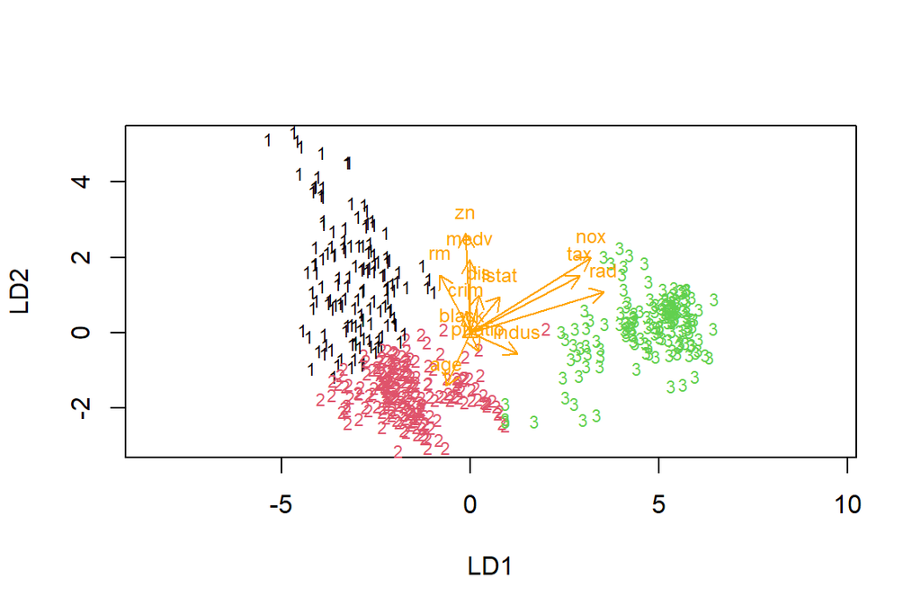

```r
# reloading data
data("Boston")

# scaling
boston_scale <- scale(Boston)
boston_scale <- as.data.frame(boston_scale)

# somehow knitting doesn't work with this varible
boston_scale <- dplyr::select(boston_scale, -chas)

set.seed(1234)

# running K-means algorithm
km <-kmeans(boston_scale, centers = 3)

# adding new clusters as target variable
clusters <- as.factor(km$cluster)

boston_scale <- mutate(boston_scale, clusters = clusters)

# running LDA
lda.fit2 <- lda(clusters ~ ., data = boston_scale)

# plotting the lda results
class <- as.numeric(boston_scale$clusters)

plot(lda.fit2, dimen = 2, col = class, pch = class)
lda.arrows(lda.fit2, myscale = 3)
```

# Dimensionality reduction techniques

## Principal Component Analysis

### Overview of the data

I am going to use the method of Principal Component Analysis (PCA) on a data set, I have constructed from Human Development Index data and Gender Inequality Index data. The purpose of this exercise is to reduce the dimensions of the resulting data set, in other words, “compress” the varibles into a smaller number of components, that we could then attempt to interpret.

This data set consists of 155 countries and 8 variables. The summary of the variables suggest, that global development is imbalanced (shoker!). For instance, we can see drastic differences between means ans medians in maternal mortality ratio (`Mat.Mor`) and adolescent birth rate (`Ado.Birth`), that suggests that there is a group of countries with very high values, pushing the mean up. Correlation plot suggests that there is a significant positive relationship between these valuables. Furthemore, the two variables have strong negative relationships with life expectancy (`Life.Exp`), education expectancy (`Edu.Exp`) and the ratio of female and male secondary education expectancy (`Edu2.FM`).

Also can be of interest a dramatic rise from min to 1st quantile in `Edu2.FM`, and the ration of participation in the labor market (`Labo.FM`).

```r
library(tidyr)
library(dplyr)
library(ggplot2)
library(GGally)
library(corrplot)


# reading the data

human <- read.table("http://s3.amazonaws.com/assets.datacamp.com/production/course_2218/datasets/human2.txt", sep = ",", header = TRUE)

str(human)
```

```
## 'data.frame':    155 obs. of  8 variables:
##  $ Edu2.FM  : num  1.007 0.997 0.983 0.989 0.969 ...
##  $ Labo.FM  : num  0.891 0.819 0.825 0.884 0.829 ...
##  $ Edu.Exp  : num  17.5 20.2 15.8 18.7 17.9 16.5 18.6 16.5 15.9 19.2 ...
##  $ Life.Exp : num  81.6 82.4 83 80.2 81.6 80.9 80.9 79.1 82 81.8 ...
##  $ GNI      : int  64992 42261 56431 44025 45435 43919 39568 52947 42155 32689 ...
##  $ Mat.Mor  : int  4 6 6 5 6 7 9 28 11 8 ...
##  $ Ado.Birth: num  7.8 12.1 1.9 5.1 6.2 3.8 8.2 31 14.5 25.3 ...
##  $ Parli.F  : num  39.6 30.5 28.5 38 36.9 36.9 19.9 19.4 28.2 31.4 ...
```

```r
# summaries of variables
summary(human)
```

```
##     Edu2.FM          Labo.FM          Edu.Exp         Life.Exp
##  Min.   :0.1717   Min.   :0.1857   Min.   : 5.40   Min.   :49.00
##  1st Qu.:0.7264   1st Qu.:0.5984   1st Qu.:11.25   1st Qu.:66.30
##  Median :0.9375   Median :0.7535   Median :13.50   Median :74.20
##  Mean   :0.8529   Mean   :0.7074   Mean   :13.18   Mean   :71.65
##  3rd Qu.:0.9968   3rd Qu.:0.8535   3rd Qu.:15.20   3rd Qu.:77.25
##  Max.   :1.4967   Max.   :1.0380   Max.   :20.20   Max.   :83.50
##       GNI            Mat.Mor         Ado.Birth         Parli.F
##  Min.   :   581   Min.   :   1.0   Min.   :  0.60   Min.   : 0.00
##  1st Qu.:  4198   1st Qu.:  11.5   1st Qu.: 12.65   1st Qu.:12.40
##  Median : 12040   Median :  49.0   Median : 33.60   Median :19.30
##  Mean   : 17628   Mean   : 149.1   Mean   : 47.16   Mean   :20.91
##  3rd Qu.: 24512   3rd Qu.: 190.0   3rd Qu.: 71.95   3rd Qu.:27.95
##  Max.   :123124   Max.   :1100.0   Max.   :204.80   Max.   :57.50
```

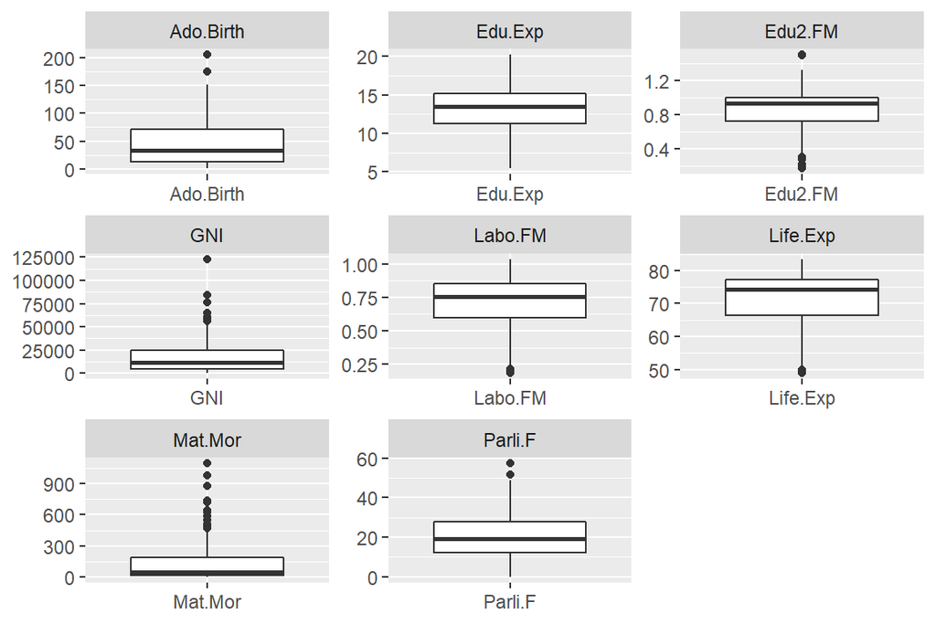

```r
# visual summary
gather(human) %>% ggplot(aes(x = key,y = value)) + facet_wrap("key", scales = "free") + geom_boxplot() + labs(x = NULL, y = NULL)
```

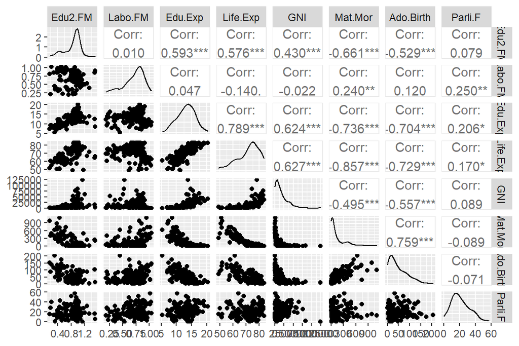

```r
# correlation plots
ggpairs(human)
```

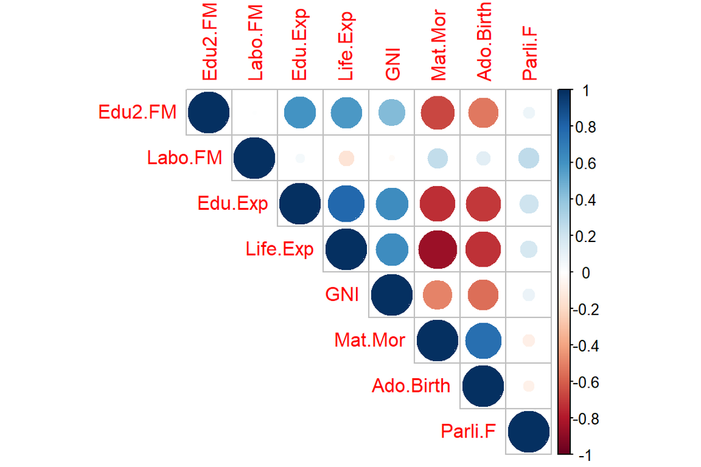

```r
cor(human) %>% corrplot(type = "upper")
```

### PCA on not-standardized data set

```r
# display variance
human %>% summarise_all(var)
```

```
##     Edu2.FM    Labo.FM  Edu.Exp Life.Exp       GNI  Mat.Mor Ado.Birth  Parli.F
## 1 0.0583897 0.03951293 8.067024 69.42328 343874462 44854.83  1690.201 131.9683
```

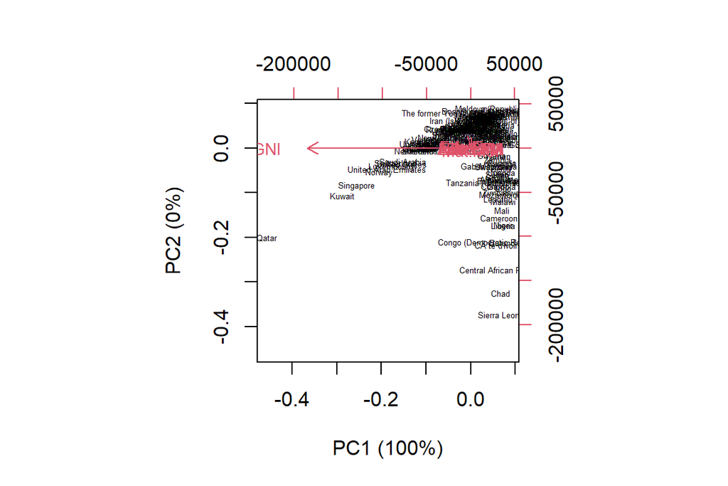

```r
# running pca
pca_human <- prcomp(human)

# calculating percentages of variance
s <- summary(pca_human)
pca_pr <- round(100*s$importance[2, ], digits = 1)

# drawing a biplot
## creating labels
pc_lab <- paste0(names(pca_pr), " (", pca_pr, "%)")

## biplot
biplot(pca_human, choices = 1:2, cex = c(0.4, 0.8), xlab = pc_lab[1], ylab = pc_lab[2])
```

### PCA on standardized data set

```r
# scaling the data set
human_std <- scale(human) %>% as.data.frame()

# scaled variance
human_std %>% summarise_all(var)
```

```
##   Edu2.FM Labo.FM Edu.Exp Life.Exp GNI Mat.Mor Ado.Birth Parli.F
## 1       1       1       1        1   1       1         1       1
```

```r
# running pca
pca_human_std <- prcomp(human_std)
pca_human_std
```

```
## Standard deviations (1, .., p=8):
## [1] 2.0708380 1.1397204 0.8750485 0.7788630 0.6619563 0.5363061 0.4589994
## [8] 0.3222406
##
## Rotation (n x k) = (8 x 8):
##                   PC1         PC2         PC3         PC4        PC5
## Edu2.FM   -0.35664370  0.03796058 -0.24223089  0.62678110 -0.5983585
## Labo.FM    0.05457785  0.72432726 -0.58428770  0.06199424  0.2625067
## Edu.Exp   -0.42766720  0.13940571 -0.07340270 -0.07020294  0.1659678
## Life.Exp  -0.44372240 -0.02530473  0.10991305 -0.05834819  0.1628935
## GNI       -0.35048295  0.05060876 -0.20168779 -0.72727675 -0.4950306
## Mat.Mor    0.43697098  0.14508727 -0.12522539 -0.25170614 -0.1800657
## Ado.Birth  0.41126010  0.07708468  0.01968243  0.04986763 -0.4672068
## Parli.F   -0.08438558  0.65136866  0.72506309  0.01396293 -0.1523699
##                   PC6         PC7         PC8
## Edu2.FM    0.17713316  0.05773644  0.16459453
## Labo.FM   -0.03500707 -0.22729927 -0.07304568
## Edu.Exp   -0.38606919  0.77962966 -0.05415984
## Life.Exp  -0.42242796 -0.43406432  0.62737008
## GNI        0.11120305 -0.13711838 -0.16961173
## Mat.Mor    0.17370039  0.35380306  0.72193946
## Ado.Birth -0.76056557 -0.06897064 -0.14335186
## Parli.F    0.13749772  0.00568387 -0.02306476
```

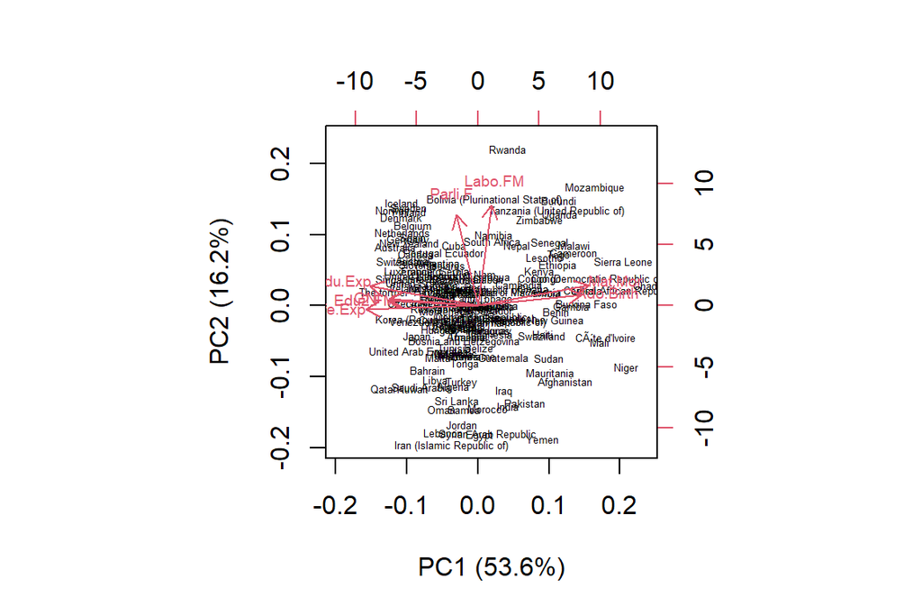

```r
# calculating percentages of variance
s2 <- summary(pca_human_std)
pcapr <- round(100*s2$importance[2, ], digits = 1)

# drawing a biplot
## creating labels
pc_lab2 <- paste0(names(pcapr), " (", pcapr, "%)")


## biplot
biplot(pca_human_std, choices = 1:2, cex = c(0.4, 0.6), xlab = pc_lab2[1], ylab = pc_lab2[2])
```

### Interpretation

PCA on not-standardized data shows that GNI as a variable with the highest variance is enough to predict the overall variance of the data set.

When the data set is scaled, the variance of each variable is 1, and we can see that principal components has become more multifaceted. The second biplot demonstrates that:

- PC1 of a country is pulled to positive values by adolescent birth rate and maternal mortality ratio. It is pulled to negative values by GNI, life expectancy at birth, expectancy of education and secondary education ratio between women and men.
- PC2 of a country is pulled to positive values by women’s labour force participation rate and proportion of women in parliament.

Overall, PC1 could be regarded as women’s quality of life index, PC2 - as women’s societal integration index.

## Multipal Correspondence Analysis

### Data

Multiple Correspondence Analysis (MCA) is a technique that can help to understand proximities between categorical variables by plotting them against two dimensions, we construct in a way similar to PCA. For this exersice I am using tea data set from the packsge FactoMineR, that records various attributes of tea consumtion. It consists of 300 observations over 36 varianles. Below is the summary and the graphic overvie of this data.

```r
# reading the data
library(FactoMineR)
data("tea")

# overview
str(tea)
```

```
## 'data.frame':    300 obs. of  36 variables:
##  $ breakfast       : Factor w/ 2 levels "breakfast","Not.breakfast": 1 1 2 2 1 2 1 2 1 1 ...
##  $ tea.time        : Factor w/ 2 levels "Not.tea time",..: 1 1 2 1 1 1 2 2 2 1 ...
##  $ evening         : Factor w/ 2 levels "evening","Not.evening": 2 2 1 2 1 2 2 1 2 1 ...
##  $ lunch           : Factor w/ 2 levels "lunch","Not.lunch": 2 2 2 2 2 2 2 2 2 2 ...
##  $ dinner          : Factor w/ 2 levels "dinner","Not.dinner": 2 2 1 1 2 1 2 2 2 2 ...
##  $ always          : Factor w/ 2 levels "always","Not.always": 2 2 2 2 1 2 2 2 2 2 ...
##  $ home            : Factor w/ 2 levels "home","Not.home": 1 1 1 1 1 1 1 1 1 1 ...
##  $ work            : Factor w/ 2 levels "Not.work","work": 1 1 2 1 1 1 1 1 1 1 ...
##  $ tearoom         : Factor w/ 2 levels "Not.tearoom",..: 1 1 1 1 1 1 1 1 1 2 ...
##  $ friends         : Factor w/ 2 levels "friends","Not.friends": 2 2 1 2 2 2 1 2 2 2 ...
##  $ resto           : Factor w/ 2 levels "Not.resto","resto": 1 1 2 1 1 1 1 1 1 1 ...
##  $ pub             : Factor w/ 2 levels "Not.pub","pub": 1 1 1 1 1 1 1 1 1 1 ...
##  $ Tea             : Factor w/ 3 levels "black","Earl Grey",..: 1 1 2 2 2 2 2 1 2 1 ...
##  $ How             : Factor w/ 4 levels "alone","lemon",..: 1 3 1 1 1 1 1 3 3 1 ...
```

[output cut: 22 more lines]

```r
summary(tea)
```

```
##          breakfast           tea.time          evening          lunch
##  breakfast    :144   Not.tea time:131   evening    :103   lunch    : 44
##  Not.breakfast:156   tea time    :169   Not.evening:197   Not.lunch:256
##
##
##
##
##
##         dinner           always          home           work
##  dinner    : 21   always    :103   home    :291   Not.work:213
##  Not.dinner:279   Not.always:197   Not.home:  9   work    : 87
##
##
##
##
##
##         tearoom           friends          resto          pub
##  Not.tearoom:242   friends    :196   Not.resto:221   Not.pub:237
##  tearoom    : 58   Not.friends:104   resto    : 79   pub    : 63
##
##
##
##
##
##         Tea         How           sugar                     how
##  black    : 74   alone:195   No.sugar:155   tea bag           :170
##  Earl Grey:193   lemon: 33   sugar   :145   tea bag+unpackaged: 94
##  green    : 33   milk : 63                  unpackaged        : 36
##                  other:  9
##
##
##
##                   where                 price          age        sex
##  chain store         :192   p_branded      : 95   Min.   :15.00   F:178
##  chain store+tea shop: 78   p_cheap        :  7   1st Qu.:23.00   M:122
##  tea shop            : 30   p_private label: 21   Median :32.00
##                             p_unknown      : 12   Mean   :37.05
##                             p_upscale      : 53   3rd Qu.:48.00
##                             p_variable     :112   Max.   :90.00
##
```

[output cut: 25 more lines]

```
##  feminine    :129   Not.sophisticated: 85   No.slimming:255   exciting   :116
##  Not.feminine:171   sophisticated    :215   slimming   : 45   No.exciting:184
##
##
##
##
##
##         relaxing              effect.on.health
##  No.relaxing:113   effect on health   : 66
##  relaxing   :187   No.effect on health:234
##
##
##
##
##
```

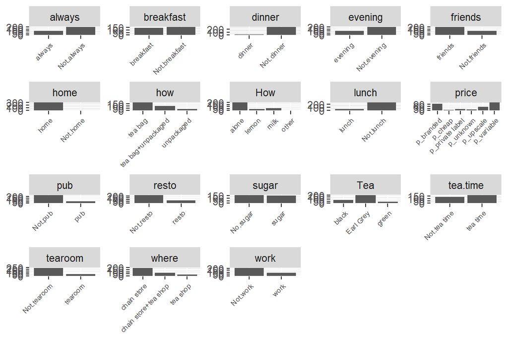

```r
gather(tea[1:18]) %>% ggplot(aes(value)) + facet_wrap("key", scales = "free") + geom_bar() + theme(axis.text.x = element_text(angle = 45, hjust = 1, size = 6))+ labs(x = NULL, y = NULL)
```

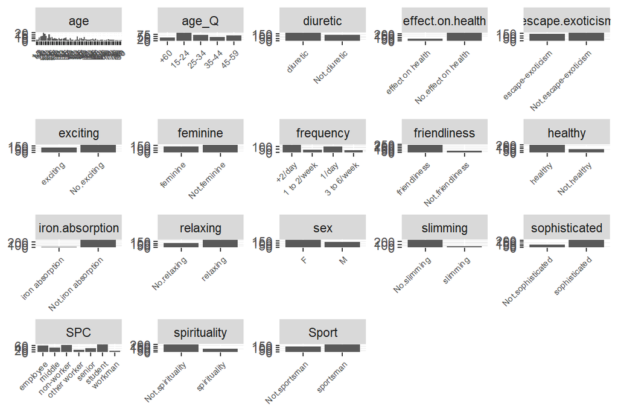

```r
gather(tea[19:36]) %>% ggplot(aes(value)) + facet_wrap("key", scales = "free") + geom_bar() + theme(axis.text.x = element_text(angle = 45, hjust = 1, size = 6))+ labs(x = NULL, y = NULL)
```

### MCA

To demonstrate how MCA is used and interpreted I am going to select 8 variables from tea data set. We are going to see how the choice of the product, modes of tea consumption and circumstances of drinking it (meals of the day) are related to each other.

Examination of MCA plot reveals some interesting patterns:

- Green tea consumption seems to occur during dinner time, while consumption of black tea and Earl Grey seems to be rather independent from meals of the day.
- People who prefer packaged tea tend to shop in chain store markets, whereas those who prefer unpackaged – at tea shops.
- Earl Grey is often consumed with sugar, while black tea for many goes well with lemon.

```r
# selecting columns
keep_columns <- c("Tea", "How", "how", "sugar", "where", "lunch", "breakfast", "dinner")

tea_time <- dplyr::select(tea, one_of(keep_columns))

# multiple correspondence analysis
mca <- MCA(tea_time, graph = FALSE)

# summary of the model
summary(mca)
```

```
##
## Call:
## MCA(X = tea_time, graph = FALSE)
##
##
## Eigenvalues
##                        Dim.1   Dim.2   Dim.3   Dim.4   Dim.5   Dim.6   Dim.7
## Variance               0.212   0.204   0.166   0.161   0.143   0.127   0.110
## % of var.             13.073  12.557  10.232   9.926   8.790   7.803   6.754
## Cumulative % of var.  13.073  25.630  35.861  45.787  54.577  62.380  69.134
##                        Dim.8   Dim.9  Dim.10  Dim.11  Dim.12  Dim.13
## Variance               0.108   0.103   0.100   0.086   0.060   0.044
## % of var.              6.674   6.317   6.141   5.307   3.694   2.733
## Cumulative % of var.  75.808  82.125  88.266  93.573  97.267 100.000
##
## Individuals (the 10 first)
##                       Dim.1    ctr   cos2    Dim.2    ctr   cos2    Dim.3
## 1                  | -0.231  0.084  0.058 | -0.226  0.083  0.056 | -0.413
## 2                  | -0.326  0.167  0.082 |  0.036  0.002  0.001 | -0.859
## 3                  |  0.132  0.027  0.008 | -0.633  0.655  0.181 |  0.262
## 4                  |  0.039  0.002  0.001 | -0.738  0.889  0.244 |  0.610
## 5                  | -0.279  0.122  0.133 | -0.253  0.105  0.110 | -0.269
## 6                  |  0.132  0.027  0.008 | -0.633  0.655  0.181 |  0.262
## 7                  | -0.279  0.122  0.133 | -0.253  0.105  0.110 | -0.269
## 8                  | -0.176  0.049  0.024 | -0.156  0.040  0.019 | -0.679
## 9                  | -0.288  0.130  0.057 |  0.835  1.138  0.480 | -0.070
## 10                 |  0.041  0.003  0.001 |  0.809  1.069  0.480 | -0.465
##                       ctr   cos2
## 1                   0.343  0.187 |
## 2                   1.478  0.567 |
## 3                   0.137  0.031 |
## 4                   0.745  0.166 |
## 5                   0.145  0.124 |
## 6                   0.137  0.031 |
## 7                   0.145  0.124 |
## 8                   0.925  0.360 |
## 9                   0.010  0.003 |
## 10                  0.434  0.159 |
##
## Categories (the 10 first)
```

[output cut: 18 more lines]

```
## other                4.568 |  -1.001   2.262   0.031  -3.045 |
## tea bag            -11.023 |  -0.108   0.495   0.015  -2.132 |
## tea bag+unpackaged  11.452 |   0.324   2.477   0.048   3.787 |
## unpackaged           0.462 |  -0.337   1.028   0.016  -2.155 |
##
## Categorical variables (eta2)
##                      Dim.1 Dim.2 Dim.3
## Tea                | 0.144 0.099 0.461 |
## How                | 0.102 0.183 0.239 |
## how                | 0.596 0.478 0.053 |
## sugar              | 0.029 0.036 0.322 |
## where              | 0.670 0.616 0.057 |
## lunch              | 0.021 0.070 0.028 |
## breakfast          | 0.076 0.121 0.085 |
## dinner             | 0.060 0.030 0.086 |
```

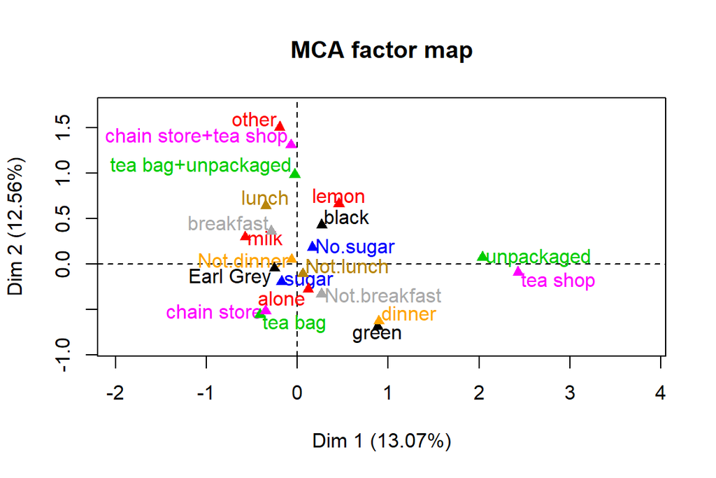

```r
# visualize MCA
plot(mca, invisible=c("ind"), habillage = "quali", graph.type = "classic")
```

We can plot not only variables, but also individuals. While the first plot shows that there is some over lap in habits between the drinkers of different kinds of tea, the second plot reveals that the sample is separated into three rather distinct group when it comes to where tea is bought.

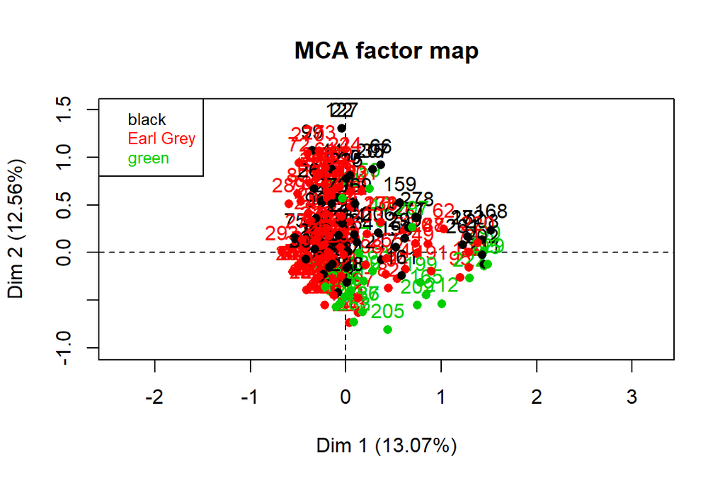

```r
plot(mca, invisible=c("var"), habillage = "Tea", graph.type = "classic")
```

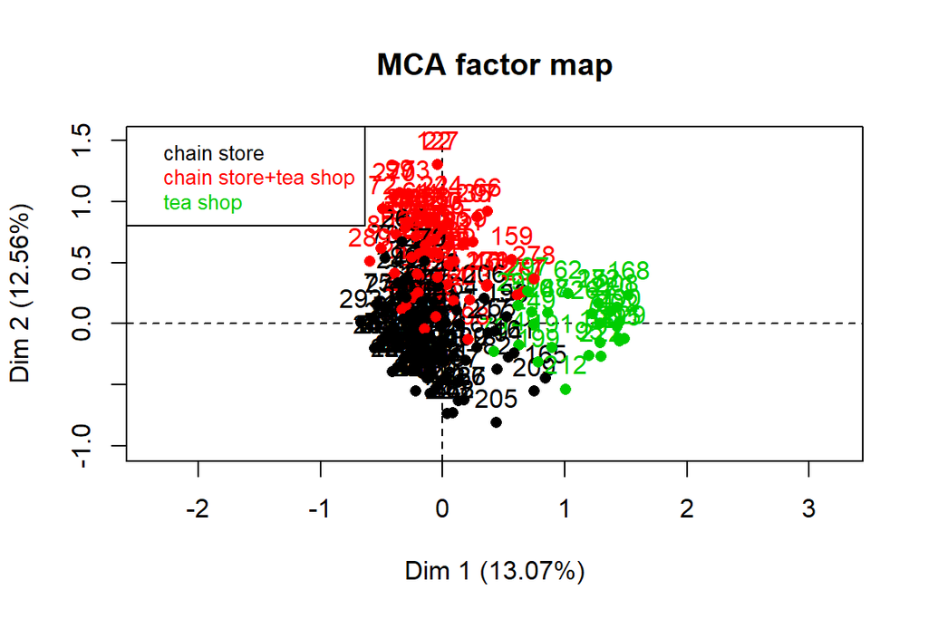

```r
plot(mca, invisible=c("var"), habillage = "where", graph.type = "classic")
```

# Analysis of longitudinal data

In this chapter I am going to demonstrate techniques used to analyze longitudinal data.

```r
# reading the data for this chapter
RATSL <- read.table(file = "Z:\\Documents\\RProjects\\IODS-project\\data\\RATSL.csv", header = TRUE, sep = ",", row.names = 1)

BPRSL <- read.table(file = "Z:\\Documents\\RProjects\\IODS-project\\data\\BPRSL.csv", header = TRUE, sep = ",", row.names = 1)

# libraries used
library(tidyr)
library(dplyr)
library(ggplot2)
library(lme4)
library(cowplot)
```

## Impact of nutrition on growth

### Overview of the data

The first technique – *summary measure approach* – is going to be tested on RATS data set (see [Crowder & Hand 1990](https://www.taylorfrancis.com/books/mono/10.1201/9781315137421/analysis-repeated-measures-crowder-hand)). The data set records weights of three groups of rats on different diets over the period of 64 days.

```r
# structure of the data set
glimpse(RATSL)
```

```
## Rows: 176
## Columns: 5
## $ ID      <int> 1, 2, 3, 4, 5, 6, 7, 8, 9, 10, 11, 12, 13, 14, 15, 16, 1, 2, 3~
## $ Group   <int> 1, 1, 1, 1, 1, 1, 1, 1, 2, 2, 2, 2, 3, 3, 3, 3, 1, 1, 1, 1, 1,~
## $ days    <chr> "WD1", "WD1", "WD1", "WD1", "WD1", "WD1", "WD1", "WD1", "WD1",~
## $ weights <int> 240, 225, 245, 260, 255, 260, 275, 245, 410, 405, 445, 555, 47~
## $ day     <int> 1, 1, 1, 1, 1, 1, 1, 1, 1, 1, 1, 1, 1, 1, 1, 1, 8, 8, 8, 8, 8,~
```

```r
# transforming categorical variables into factor
cat_vars2 <- c("ID", "Group")
RATSL[cat_vars2] <- lapply(RATSL[cat_vars2], factor)
```

### Graphical display of growth

To start with, let’s investigate plots of growth profiles by group. According to Figure 1.1, all diets seem to result in growth of rat’s body mass, however, group 1 demonstrates a more moderate trend than the other two.

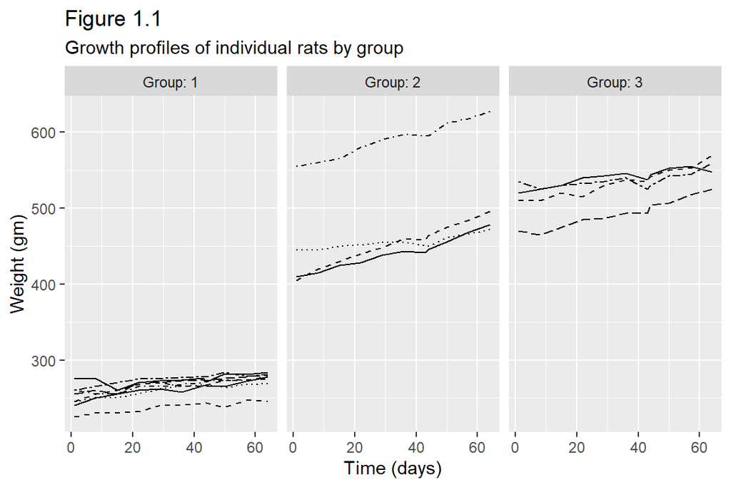

```r
# drawing the plot
ggplot(RATSL, aes(x = day, y = weights, linetype = ID)) +
  geom_line() +
  scale_linetype_manual(values = rep(1:8, times=2)) +
  facet_grid(. ~ Group, labeller = label_both) +
  theme(legend.position = "none") +
  scale_y_continuous(limits = c(min(RATSL$weights), max(RATSL$weights))) + labs(y = "Weight (gm)", x = "Time (days)", title = "Figure 1.1", subtitle = "Growth profiles of individual rats by group")
```

Let’s standardize weights to observe *tracking*, a tendency for subjects with higher values to have higher values throughout the study. Figure 1.2 shows that growth trend for some rats is reversed, and overall, now growth trends appear less dramatic.

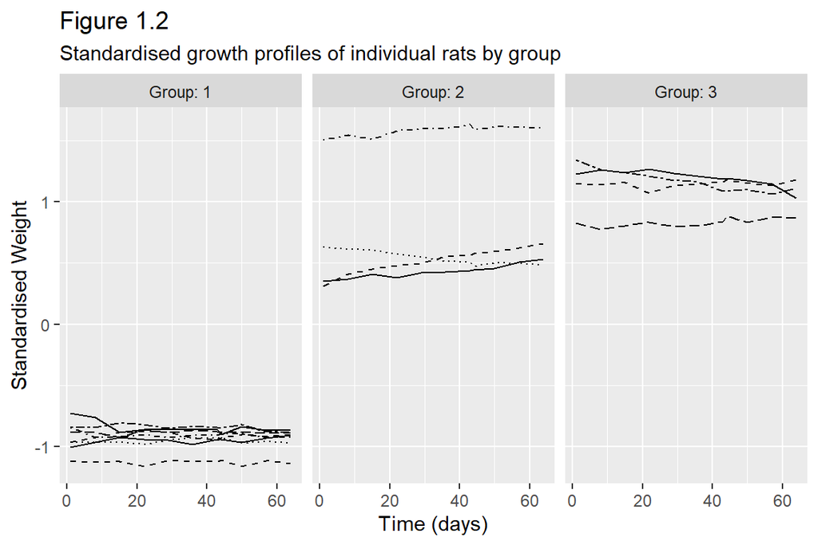

```r
# standardizing weights
RATSL <- RATSL %>% group_by(day) %>%
  mutate(std_weights = scale(weights) )  %>%
  ungroup()

# drawing new plot
ggplot(RATSL, aes(x = day, y = std_weights, linetype = ID)) +
  geom_line() +
  scale_linetype_manual(values = rep(1:8, times=2)) +
  facet_grid(. ~ Group, labeller = label_both) +
  theme(legend.position = "none") +
  scale_y_continuous(limits = c(min(RATSL$std_weights), max(RATSL$std_weights))) + labs(y = "Standardised Weight", x = "Time (days)", title = "Figure 1.2", subtitle = "Standardised growth profiles of individual rats by group")
```

By plotting the means of the three groups, it is possible to observe that the groups appear to have distinct profiles. Although group 2 and 3 seem very close, they do not overlap.

```r
# extracting number of days measurements were made
n <- RATSL$day %>% unique() %>% length()

# summary data with mean and standard error of weights by group and day
RATSS <- RATSL %>%
  group_by(Group, day) %>%
  summarise( mean = mean(weights), se = sd(weights)/sqrt(n) ) %>%
  ungroup()
```

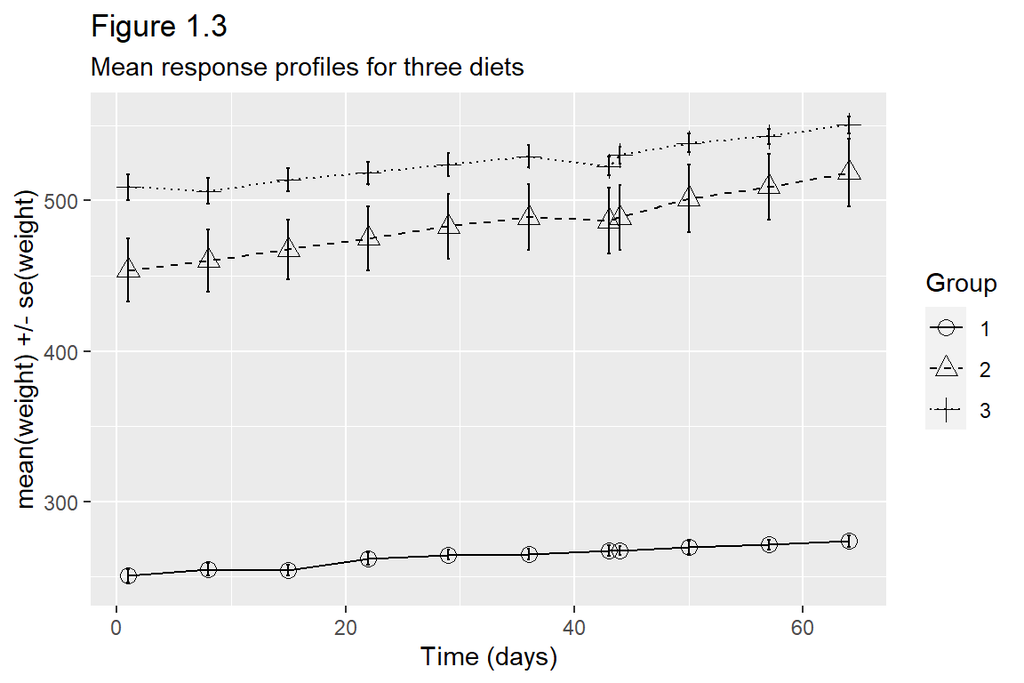

```r
ggplot(RATSS, aes(x = day, y = mean, linetype = Group, shape = Group)) +
  geom_line() +
  scale_linetype_manual(values = c(1,2,3)) +
  geom_point(size=3) +
  scale_shape_manual(values = c(1,2,3)) +
  geom_errorbar(aes(ymin=mean-se, ymax=mean+se, linetype="1"), width=0.3) +
  theme(legend.position = "right") +
  scale_y_continuous(name = "mean(weight) +/- se(weight)") + labs(x = "Time (days)", title = "Figure 1.3", subtitle = "Mean response profiles for three diets")
```

### Summary measure analysis

Summary measure analysis implies exploring the difference between groups on the basis of a single value, which captures some important characteristic of each group. This technique is commonly used as a preliminary stage for longitudinal data analysis. For the purposes of this exercise I am going to use the mean as a summary measure.

Boxplots of mean profiles (Figure 1.4) indicate that groups seem to be different. Group 1 has the least variability. Meanwhile, group 2 and 3 seem somewhat skewed into the opposite directions. The groups have no outliers.

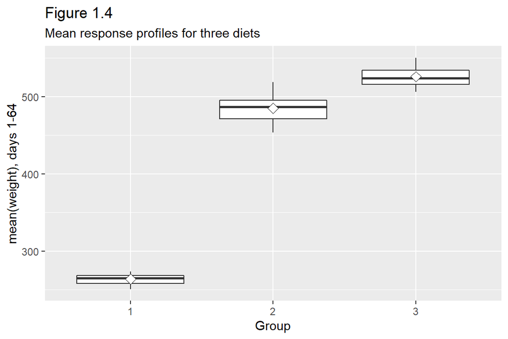

```r
# draw boxplots for groups
ggplot(RATSS, aes(x = Group, y = mean)) +
  geom_boxplot() +
  stat_summary(fun.y = "mean", geom = "point", shape=23, size=3, fill = "white") +
  scale_y_continuous(name = "mean(weight), days 1-64") +
  labs(title = "Figure 1.4", subtitle = "Mean response profiles for three diets")
```

### One-way analysis of variance (ANOVA)

In order to confirm that the diets indeed have a different impact on growth, I am going to conduct one-way analysis of variance (ANOVA) on the means. The resulting *p* value is smaller than 0.05, thus, we can conclude that groups 2 and 3 differ significantly from group 1. Next, I am performing a post hoc test (Tuckey test), to be sure that all groups also differ from each other. As *p* values of the test suggest, it is indeed so.

```r
# fitting anova
ratss_aov <- aov(mean ~  Group, data = RATSS)
summary(ratss_aov)
```

```
##             Df Sum Sq Mean Sq F value Pr(>F)
## Group        2 437104  218552    1006 <2e-16 ***
## Residuals   30   6516     217
## ---
## Signif. codes:  0 '***' 0.001 '**' 0.01 '*' 0.05 '.' 0.1 ' ' 1
```

```r
# post-hoc test
TukeyHSD(ratss_aov)
```

```
##   Tukey multiple comparisons of means
##     95% family-wise confidence level
##
## Fit: aov(formula = mean ~ Group, data = RATSS)
##
## $Group
##          diff       lwr       upr p adj
## 2-1 220.98864 205.49700 236.48027 0e+00
## 3-1 262.07955 246.58791 277.57118 0e+00
## 3-2  41.09091  25.59927  56.58254 9e-07
```

## Effects of different treatments on brief psychiatric rating scale

### Overview of the data

In this section I am going to use *linear mixed effect model* approach. For this exercise I am using the data set from [Davis 2002](https://link.springer.com/book/10.1007/b97287). It is taken from brief psychiatric rating scale (BPRS) study conducted over a period of 9 weeks on 40 men, who were divided into two treatment groups.

```r
# structure of the data
glimpse(BPRSL)
```

```
## Rows: 360
## Columns: 6
## $ treatment <int> 1, 1, 1, 1, 1, 1, 1, 1, 1, 1, 1, 1, 1, 1, 1, 1, 1, 1, 1, 1, ~
## $ subject   <int> 1, 2, 3, 4, 5, 6, 7, 8, 9, 10, 11, 12, 13, 14, 15, 16, 17, 1~
## $ id        <int> 1, 2, 3, 4, 5, 6, 7, 8, 9, 10, 11, 12, 13, 14, 15, 16, 17, 1~
## $ weeks     <chr> "week0", "week0", "week0", "week0", "week0", "week0", "week0~
## $ bprs      <int> 42, 58, 54, 55, 72, 48, 71, 30, 41, 57, 30, 55, 36, 38, 66, ~
## $ week      <int> 0, 0, 0, 0, 0, 0, 0, 0, 0, 0, 0, 0, 0, 0, 0, 0, 0, 0, 0, 0, ~
```

```r
# transforming categorical variables into factors
cat_vars <- c("treatment", "subject", "id")
BPRSL[cat_vars] <- lapply(BPRSL[cat_vars], factor)
```

### Graphical display

First, let’s graphically explore the data (Figure 2.1). At first glance, both groups express a downward trend in BPRS measure. The plot does not reveal an obvious diffetence between two treatments.

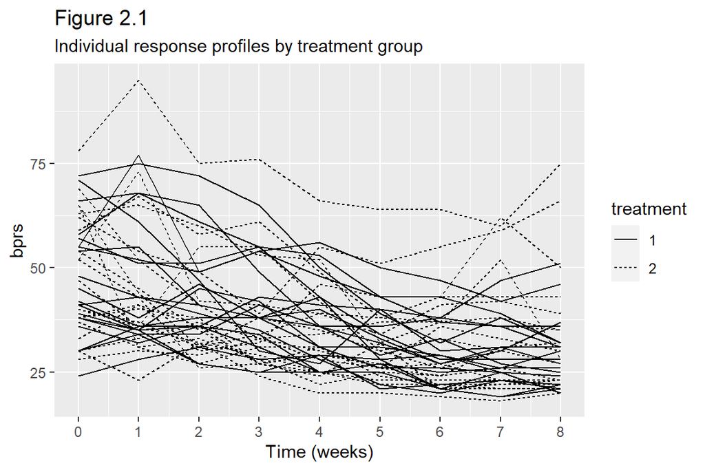

```r
obs_plot <- ggplot(BPRSL, aes(x = week, y = bprs, group = id)) +
  geom_line(aes(linetype = treatment)) +
  scale_x_continuous(name = "Time (weeks)", breaks = seq(0, 8, 1))

obs_plot +
  labs(title = "Figure 2.1", subtitle= "Individual response profiles by treatment group")
```

### Assuming independence

Before testing linear mixed effect modelling, I am going to wrongly (!) assume that the measurements are independent from each other and fit a multiple linear regression model. In other words, I treat the data set as if there are 360 observations from different people. Ignoring within-subject dependencies leads to higher standard error estimates for the `week` regression coefficient. In this case it is 0.2524.

```r
# fit model assuming independence
bprs_m0 <- lm(bprs ~ week + treatment, data = BPRSL)
summary(bprs_m0)
```

```
##
## Call:
## lm(formula = bprs ~ week + treatment, data = BPRSL)
##
## Residuals:
##     Min      1Q  Median      3Q     Max
## -22.454  -8.965  -3.196   7.002  50.244
##
## Coefficients:
##             Estimate Std. Error t value Pr(>|t|)
## (Intercept)  46.4539     1.3670  33.982   <2e-16 ***
## week         -2.2704     0.2524  -8.995   <2e-16 ***
## treatment2    0.5722     1.3034   0.439    0.661
## ---
## Signif. codes:  0 '***' 0.001 '**' 0.01 '*' 0.05 '.' 0.1 ' ' 1
##
## Residual standard error: 12.37 on 357 degrees of freedom
## Multiple R-squared:  0.1851, Adjusted R-squared:  0.1806
## F-statistic: 40.55 on 2 and 357 DF,  p-value: < 2.2e-16
```

### Linear mixed effects models

Now I am going to demonsterate more appropriate models for repeated measurements data.

First, I am fitting a mixed effect model with random intercept. By allowing the intercept to be different we can account for difference between subjects. Immediately we can observe that standard error for `week` is considerably lower – only 0.1503.

Regression coefficient for `treatment` has a very low t-value, which suggests that that the null hypothesis might be true, and there is no difference between the two groups.

Nevertheless, I am going to do another fit with random intercept and random slope. This model allows duration of treatment to have an effect on the slope. Again, t-value for `treatment` is close to 0.

Next, we are going to allow interaction between treatment and time. In this case too, the result appears to suggest that the treatment does not have a different effect on BPRS.

```r
# fit model with random intercept
bprs_m1 <- lmer(bprs ~ week + treatment + (1|id), data = BPRSL, REML = FALSE)
summary(bprs_m1)
```

```
## Linear mixed model fit by maximum likelihood  ['lmerMod']
## Formula: bprs ~ week + treatment + (1 | id)
##    Data: BPRSL
##
##      AIC      BIC   logLik deviance df.resid
##   2582.9   2602.3  -1286.5   2572.9      355
##
## Scaled residuals:
##      Min       1Q   Median       3Q      Max
## -2.27506 -0.59909 -0.06104  0.44226  3.15835
##
## Random effects:
##  Groups   Name        Variance Std.Dev.
##  id       (Intercept) 97.39    9.869
##  Residual             54.23    7.364
## Number of obs: 360, groups:  id, 40
##
## Fixed effects:
##             Estimate Std. Error t value
## (Intercept)  46.4539     2.3521  19.750
## week         -2.2704     0.1503 -15.104
## treatment2    0.5722     3.2159   0.178
##
## Correlation of Fixed Effects:
##            (Intr) week
## week       -0.256
## treatment2 -0.684  0.000
```

```r
# fit model with random intercept and random slope
bprs_m2 <- lmer(bprs ~ week + treatment + (week|id), data = BPRSL, REML = FALSE)
summary(bprs_m2)
```

```
## Linear mixed model fit by maximum likelihood  ['lmerMod']
## Formula: bprs ~ week + treatment + (week | id)
##    Data: BPRSL
##
##      AIC      BIC   logLik deviance df.resid
##   2523.2   2550.4  -1254.6   2509.2      353
##
## Scaled residuals:
##     Min      1Q  Median      3Q     Max
## -2.4655 -0.5150 -0.0920  0.4347  3.7353
##
## Random effects:
##  Groups   Name        Variance Std.Dev. Corr
##  id       (Intercept) 167.827  12.955
##           week          2.331   1.527   -0.67
##  Residual              36.747   6.062
## Number of obs: 360, groups:  id, 40
##
## Fixed effects:
##             Estimate Std. Error t value
## (Intercept)  45.9830     2.6470  17.372
## week         -2.2704     0.2713  -8.370
## treatment2    1.5139     3.1392   0.482
##
## Correlation of Fixed Effects:
##            (Intr) week
## week       -0.545
## treatment2 -0.593  0.000
```

```r
# compare models
anova(bprs_m1, bprs_m2)
```

```
## Data: BPRSL
## Models:
## bprs_m1: bprs ~ week + treatment + (1 | id)
## bprs_m2: bprs ~ week + treatment + (week | id)
##         npar    AIC    BIC  logLik deviance  Chisq Df Pr(>Chisq)
## bprs_m1    5 2582.9 2602.3 -1286.5   2572.9
## bprs_m2    7 2523.2 2550.4 -1254.6   2509.2 63.663  2  1.499e-14 ***
## ---
## Signif. codes:  0 '***' 0.001 '**' 0.01 '*' 0.05 '.' 0.1 ' ' 1
```

```r
# fit model with random intercept, random slope and interaction
bprs_m3 <- lmer(bprs ~ week + treatment + week*treatment + (week|id), data = BPRSL, REML = FALSE)
summary(bprs_m3)
```

```
## Linear mixed model fit by maximum likelihood  ['lmerMod']
## Formula: bprs ~ week + treatment + week * treatment + (week | id)
##    Data: BPRSL
##
##      AIC      BIC   logLik deviance df.resid
##   2523.5   2554.5  -1253.7   2507.5      352
##
## Scaled residuals:
##     Min      1Q  Median      3Q     Max
## -2.4747 -0.5256 -0.0866  0.4435  3.7884
##
## Random effects:
##  Groups   Name        Variance Std.Dev. Corr
##  id       (Intercept) 164.204  12.814
##           week          2.203   1.484   -0.66
##  Residual              36.748   6.062
## Number of obs: 360, groups:  id, 40
##
## Fixed effects:
##                 Estimate Std. Error t value
## (Intercept)      47.8856     2.9840  16.047
## week             -2.6283     0.3752  -7.006
## treatment2       -2.2911     4.2200  -0.543
## week:treatment2   0.7158     0.5306   1.349
##
## Correlation of Fixed Effects:
##             (Intr) week   trtmn2
## week        -0.668
## treatment2  -0.707  0.473
## wek:trtmnt2  0.473 -0.707 -0.668
```

```r
# compare models again
anova(bprs_m2, bprs_m3)
```

```
## Data: BPRSL
## Models:
## bprs_m2: bprs ~ week + treatment + (week | id)
## bprs_m3: bprs ~ week + treatment + week * treatment + (week | id)
##         npar    AIC    BIC  logLik deviance Chisq Df Pr(>Chisq)
## bprs_m2    7 2523.2 2550.4 -1254.6   2509.2
## bprs_m3    8 2523.5 2554.6 -1253.7   2507.5  1.78  1     0.1821
```

### Comparison between observed and predicted

Finally, I am going to show the earlier graph with observed values next to the one with fitted values (Figure 2.2). Looks rather accurate.

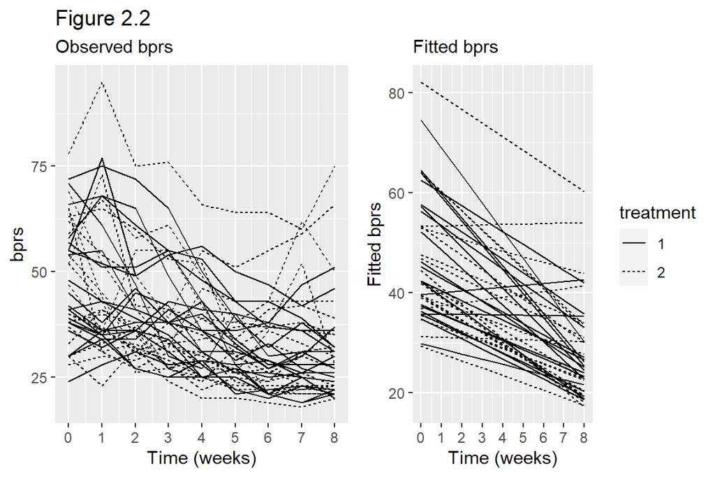

```r
# create new column with fitted bprs
Fitted <- fitted(bprs_m2)
BPRSL <- BPRSL %>% mutate(Fitted = Fitted)

# draw plots
fit_plot <- ggplot(BPRSL, aes(x = week, y = Fitted, group = id)) +
  geom_line(aes(linetype = treatment)) +
  scale_x_continuous(name = "Time (weeks)", breaks = seq(0, 8, 1)) +
  scale_y_continuous(name = "Fitted bprs")


plot_grid(obs_plot + theme(legend.position = "none") + labs(title = "Figure 2.2", subtitle = "Observed bprs"),
          fit_plot + labs(title = " ", subtitle = "Fitted bprs"),
          labels = NULL)
```